# warmup_git

Taxi Rides Dataset

Data fields

- id: a unique identifier for each trip
- vendor_id - a code indicating the provider associated with the trip record
- pickup_datetime - date and time when the meter was engaged
- dropoff_datetime - date and time when the meter was disengaged
- passenger_count - the number of passengers in the vehicle (driver entered value)
- pickup_longitude - the longitude where the meter was engaged
- pickup_latitude - the latitude where the meter was engaged
- dropoff_longitude - the longitude where the meter was disengaged
- dropoff_latitude - the latitude where the meter was disengaged
- store_and_fwd_flag - This flag indicates whether the trip record was held in vehicle memory before sending to the vendor because the vehicle did not have a connection to the server - Y=store and forward; N=not a store and forward trip
- trip_duration - duration of the trip in seconds

Our goal with the dataset is to predict the `trip_duration` depending on these variables.

Load the dataset

```python
import warnings
warnings.filterwarnings('ignore')

from IPython.core.interactiveshell import InteractiveShell
InteractiveShell.ast_node_interactivity = "all"

import seaborn as sns
import matplotlib.pyplot as plt
import pandas as pd
import numpy as np
```

```python
from sklearn.model_selection import train_test_split
from sklearn.preprocessing import StandardScaler
from sklearn.linear_model import LinearRegression
from sklearn.metrics import mean_absolute_error, mean_squared_error, r2_score, mean_squared_log_error
```

```python
df = pd.read_csv('train.csv')
df.head()
df.shape
```

|  | id | vendor_id | pickup_datetime | dropoff_datetime | passenger_count | pickup_longitude | pickup_latitude | dropoff_longitude | dropoff_latitude | store_and_fwd_flag | trip_duration |
| --- | --- | --- | --- | --- | --- | --- | --- | --- | --- | --- | --- |
| 0 | id2875421 | 2 | 2016-03-14 17:24:55 | 2016-03-14 17:32:30 | 1.0 | -73.982155 | 40.767937 | -73.964630 | 40.765602 | N | 455.0 |
| 1 | id2377394 | 1 | 2016-06-12 00:43:35 | 2016-06-12 00:54:38 | 1.0 | -73.980415 | 40.738564 | -73.999481 | 40.731152 | N | 663.0 |
| 2 | id3858529 | 2 | 2016-01-19 11:35:24 | 2016-01-19 12:10:48 | 1.0 | -73.979027 | 40.763939 | -74.005333 | 40.710087 | N | 2124.0 |
| 3 | id3504673 | 2 | 2016-04-06 19:32:31 | 2016-04-06 19:39:40 | 1.0 | -74.010040 | 40.719971 | -74.012268 | 40.706718 | N | 429.0 |
| 4 | id2181028 | 2 | 2016-03-26 13:30:55 | 2016-03-26 13:38:10 | 1.0 | -73.973053 | 40.793209 | -73.972923 | 40.782520 | N | 435.0 |

```
(58759, 11)
```

# Data exploration

```python
df.describe()
```

|  | vendor_id | passenger_count | pickup_longitude | pickup_latitude | dropoff_longitude | dropoff_latitude | trip_duration |
| --- | --- | --- | --- | --- | --- | --- | --- |
| count | 58759.000000 | 58758.000000 | 58758.000000 | 58758.000000 | 58758.000000 | 58758.000000 | 58758.000000 |
| mean | 1.530676 | 1.670649 | -73.973483 | 40.751202 | -73.973393 | 40.752015 | 942.885769 |
| std | 0.499062 | 1.319524 | 0.037966 | 0.027970 | 0.036540 | 0.032461 | 3059.443469 |
| min | 1.000000 | 1.000000 | -74.393555 | 40.449749 | -74.398514 | 40.444698 | 1.000000 |
| 25% | 1.000000 | 1.000000 | -73.991798 | 40.737560 | -73.991371 | 40.736006 | 394.000000 |
| 50% | 2.000000 | 1.000000 | -73.981644 | 40.754414 | -73.979729 | 40.754627 | 661.000000 |
| 75% | 2.000000 | 2.000000 | -73.967087 | 40.768539 | -73.962847 | 40.770007 | 1074.000000 |
| max | 2.000000 | 6.000000 | -73.518051 | 41.091171 | -72.711395 | 41.311520 | 86357.000000 |

```python
df.info()
```

```
<class 'pandas.core.frame.DataFrame'>
RangeIndex: 58759 entries, 0 to 58758
Data columns (total 11 columns):
 #   Column              Non-Null Count  Dtype
---  ------              --------------  -----
 0   id                  58759 non-null  object
 1   vendor_id           58759 non-null  int64
 2   pickup_datetime     58759 non-null  object
 3   dropoff_datetime    58759 non-null  object
 4   passenger_count     58758 non-null  float64
 5   pickup_longitude    58758 non-null  float64
 6   pickup_latitude     58758 non-null  float64
 7   dropoff_longitude   58758 non-null  float64
 8   dropoff_latitude    58758 non-null  float64
 9   store_and_fwd_flag  58758 non-null  object
 10  trip_duration       58758 non-null  float64
dtypes: float64(6), int64(1), object(4)
memory usage: 4.9+ MB
```

There's a huge outlier in `trip_duration` -- max is 85k with mean just below 1k

```python
# Nulls?
df.isnull().sum()
```

```
id                    0
vendor_id             0
pickup_datetime       0
dropoff_datetime      0
passenger_count       1
pickup_longitude      1
pickup_latitude       1
dropoff_longitude     1
dropoff_latitude      1
store_and_fwd_flag    1
trip_duration         1
dtype: int64
```

```python
# see what rows are affected
df[df.isna().any(axis=1)]
```

|  | id | vendor_id | pickup_datetime | dropoff_datetime | passenger_count | pickup_longitude | pickup_latitude | dropoff_longitude | dropoff_latitude | store_and_fwd_flag | trip_duration |
| --- | --- | --- | --- | --- | --- | --- | --- | --- | --- | --- | --- |
| 58758 | id1958270 | 1 | 2016-04-20 23:02:49 | 2016-04-20 | NaN | NaN | NaN | NaN | NaN | NaN | NaN |

```python
# with just 1 row we can drop it
df.drop(index=58758, inplace=True)
```

Trip duration distribution

Calculate the average trip duration grouped by the passengers and vendors

```python
avg_trip = df['passenger_count'].value_counts().reset_index()
avg_trip
```

|  | passenger_count | count |
| --- | --- | --- |
| 0 | 1 | 41529 |
| 1 | 2 | 8494 |
| 2 | 5 | 3203 |
| 3 | 3 | 2390 |
| 4 | 6 | 1947 |
| 5 | 4 | 1195 |

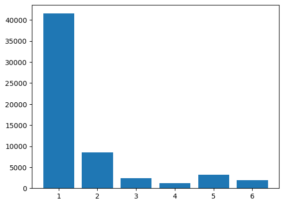

```python
plt.bar(avg_trip['passenger_count'], avg_trip['count']);
```

```python
# average trip duration by vendor and by number of passengers
avg_duration_pass = df.groupby(['passenger_count', 'vendor_id'])['trip_duration'].mean().reset_index()
avg_duration_pass
```

|  | passenger_count | vendor_id | trip_duration |
| --- | --- | --- | --- |
| 0 | 1 | 1 | 815.243791 |
| 1 | 1 | 2 | 1039.143253 |
| 2 | 2 | 1 | 926.151073 |
| 3 | 2 | 2 | 1043.442491 |
| 4 | 3 | 1 | 946.035874 |
| 5 | 3 | 2 | 1016.816422 |
| 6 | 4 | 1 | 932.677165 |
| 7 | 4 | 2 | 1065.228530 |
| 8 | 5 | 1 | 598.900000 |
| 9 | 5 | 2 | 1016.539305 |
| 10 | 6 | 1 | 1293.600000 |
| 11 | 6 | 2 | 1034.381565 |

For better representation we need to pivot table

```python
pivot_avg_duration_pass = avg_duration_pass.pivot(index='passenger_count', columns='vendor_id', values='trip_duration')
pivot_avg_duration_pass
```

| vendor_id passenger_count | 1 | 2 |
| --- | --- | --- |
| 1 | 815.243791 | 1039.143253 |
| 2 | 926.151073 | 1043.442491 |
| 3 | 946.035874 | 1016.816422 |
| 4 | 932.677165 | 1065.228530 |
| 5 | 598.900000 | 1016.539305 |
| 6 | 1293.600000 | 1034.381565 |

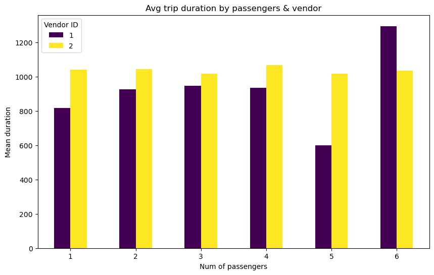

```python
pivot_avg_duration_pass.plot(kind='bar', figsize=(10, 6), colormap='viridis')

plt.title('Avg trip duration by passengers & vendor')
plt.xlabel('Num of passengers')
plt.ylabel('Mean duration')
plt.legend(title='Vendor ID')

plt.xticks(rotation=0) # don't get it why it's rotated so ...
plt.show();
```

So moatly customers prefere to use **vendor 2** in all company categories except for largest groups in terms of duration. Vendor 1 is number 1 choice for longer rides for largest company. Maybe Vendor 2 has a very limited options for that.

OK. Let's see what geography we have.

```python
from folium import FeatureGroup, LayerControl, Map, Marker
from folium.plugins import HeatMap
import folium
```

```python
plat_min = df['pickup_latitude'].min()
plon_min = df['pickup_longitude'].min()

df_pickup = df.groupby(['pickup_latitude','pickup_longitude'])['id'].count().reset_index().rename(columns={'id':'Num_Trips'})
```

```python
init_map = folium.Map(location=[plat_min, plon_min], zoom_start=10, width='95%', height='90%')

pkp_map = HeatMap(list(zip(df_pickup.pickup_latitude, df_pickup.pickup_longitude, df_pickup.Num_Trips)), min_opacity=0.9, radius=5, blur=5, max_zoom=1)

init_map.add_child(pkp_map)
```

Make this Notebook Trusted to load map: File -> Trust Notebook

[interactive chart not shown]

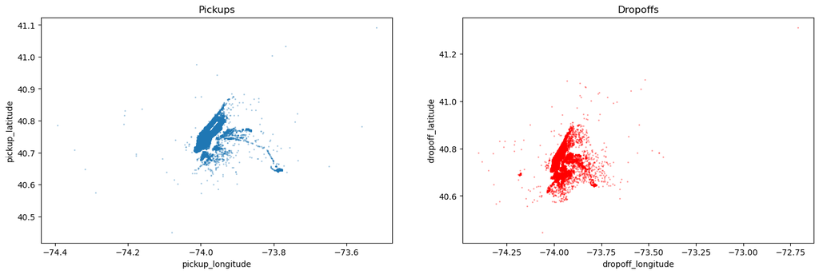

```python
# picup locations
fig, ax = plt.subplots(1,2, figsize=(17,5))

df.plot(kind="scatter", x="pickup_longitude", y="pickup_latitude", alpha=0.3, s=1, ax=ax[0]);
ax[0].set_title('Pickups')
df.plot(kind="scatter", x="dropoff_longitude", y="dropoff_latitude", alpha=0.3, s=1, color='r', ax=ax[1]);
ax[1].set_title('Dropoffs');
```

Pickup feography is less scathered. There are more putliers in dropoff.

## Convert data

### Letter class into integer

We have one feature we need to convert into integer representation -- `store_and_fwd_flag`.

```python
df['st_flag'] = df['store_and_fwd_flag'].replace({'N':0, 'Y': 1})
df.head()
```

|  | id | vendor_id | pickup_datetime | dropoff_datetime | passenger_count | pickup_longitude | pickup_latitude | dropoff_longitude | dropoff_latitude | store_and_fwd_flag | trip_duration | st_flag |
| --- | --- | --- | --- | --- | --- | --- | --- | --- | --- | --- | --- | --- |
| 0 | id2875421 | 2 | 2016-03-14 17:24:55 | 2016-03-14 17:32:30 | 1 | -73.982155 | 40.767937 | -73.964630 | 40.765602 | N | 455.0 | 0 |
| 1 | id2377394 | 1 | 2016-06-12 00:43:35 | 2016-06-12 00:54:38 | 1 | -73.980415 | 40.738564 | -73.999481 | 40.731152 | N | 663.0 | 0 |
| 2 | id3858529 | 2 | 2016-01-19 11:35:24 | 2016-01-19 12:10:48 | 1 | -73.979027 | 40.763939 | -74.005333 | 40.710087 | N | 2124.0 | 0 |
| 3 | id3504673 | 2 | 2016-04-06 19:32:31 | 2016-04-06 19:39:40 | 1 | -74.010040 | 40.719971 | -74.012268 | 40.706718 | N | 429.0 | 0 |
| 4 | id2181028 | 2 | 2016-03-26 13:30:55 | 2016-03-26 13:38:10 | 1 | -73.973053 | 40.793209 | -73.972923 | 40.782520 | N | 435.0 | 0 |

```python
df['st_flag'].value_counts()
# df['store_and_fwd_flag'].value_counts()
```

```
st_flag
0    58408
1      350
Name: count, dtype: int64
```

Just to note - imbalanced variable.

```python
df['vendor_id'].value_counts()
```

```
vendor_id
2    31182
1    27576
Name: count, dtype: int64
```

Our `id` column is object ATM, we can turn it into smth more usable:

```python
df['id'] = df['id'].str.split('id').str[1]
```

### Time vars

`pickup_datetime` and `dropoff_datetime` features are objects, so we need to convert them into proper format.

```python
df.head()
```

|  | id | vendor_id | pickup_datetime | dropoff_datetime | passenger_count | pickup_longitude | pickup_latitude | dropoff_longitude | dropoff_latitude | store_and_fwd_flag | trip_duration | st_flag |
| --- | --- | --- | --- | --- | --- | --- | --- | --- | --- | --- | --- | --- |
| 0 | 2875421 | 2 | 2016-03-14 17:24:55 | 2016-03-14 17:32:30 | 1 | -73.982155 | 40.767937 | -73.964630 | 40.765602 | N | 455.0 | 0 |
| 1 | 2377394 | 1 | 2016-06-12 00:43:35 | 2016-06-12 00:54:38 | 1 | -73.980415 | 40.738564 | -73.999481 | 40.731152 | N | 663.0 | 0 |
| 2 | 3858529 | 2 | 2016-01-19 11:35:24 | 2016-01-19 12:10:48 | 1 | -73.979027 | 40.763939 | -74.005333 | 40.710087 | N | 2124.0 | 0 |
| 3 | 3504673 | 2 | 2016-04-06 19:32:31 | 2016-04-06 19:39:40 | 1 | -74.010040 | 40.719971 | -74.012268 | 40.706718 | N | 429.0 | 0 |
| 4 | 2181028 | 2 | 2016-03-26 13:30:55 | 2016-03-26 13:38:10 | 1 | -73.973053 | 40.793209 | -73.972923 | 40.782520 | N | 435.0 | 0 |

```python
df['pickup_datetime'] = pd.to_datetime(df['pickup_datetime'])
df['dropoff_datetime'] = pd.to_datetime(df['dropoff_datetime'])
```

### Handling outliers

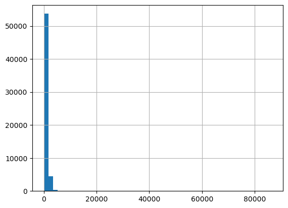

```python
df['trip_duration'].hist(bins=50);
```

Due to outliers we can't see distribution of the data: it's all tightly packed in the beginning with some outliers stretched to the end.

```python
df['trip_duration'].max()
df['trip_duration'].min()
```

```
86357.0
```

```
1.0
```

We have a ~24 hour ride around Manhattan. It looks more like not switched off meter.

Same for 1 second ride. Smth like a test maybe? Anyway we need to addres that. We'll use IQR for that.

```python
q1 = df['trip_duration'].quantile(0.25)
q3 = df['trip_duration'].quantile(0.75)
IQR = q3-q1
lower_bound = q1-1.5*IQR
upper_bound = q3+1.5*IQR
outliers = df[(df['trip_duration'] < lower_bound) | (df['trip_duration'] > upper_bound)]

len(outliers)
```

```
2958
```

So we have 3k outliers

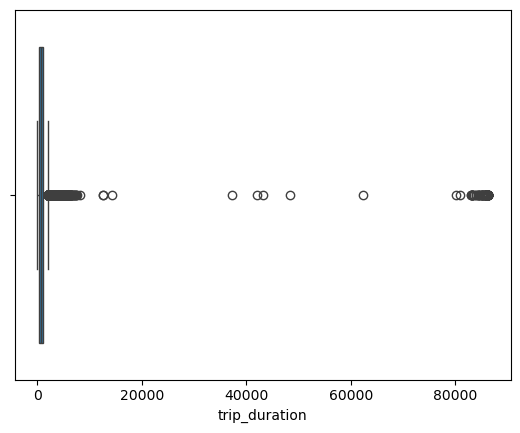

```python
sns.boxplot(x=df['trip_duration']);
```

It's hard to see anything like that. Got to transform it.

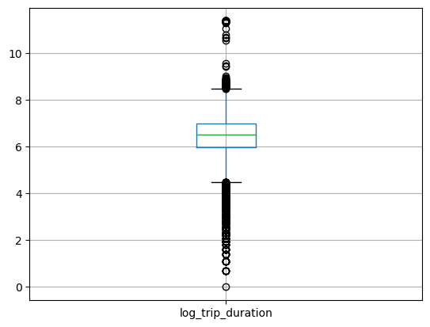

```python
df['log_trip_duration'] = np.log(df['trip_duration'])
df.boxplot('log_trip_duration');
```

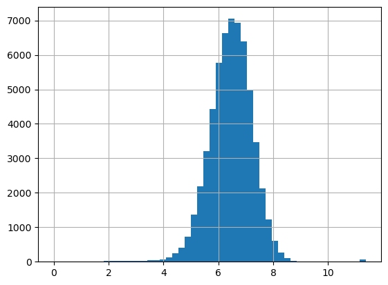

```python
df['log_trip_duration'].hist(bins=50)
```

The feature looks slightly skewed, so I have a feeling that if we remove these outlying datapoints this won't significantly change the shape of dataset.

```python
df_cleaned = df[(df['trip_duration'] >= lower_bound) & (df['trip_duration'] <= upper_bound)]
print("Data points after removing outliers:", len(df_cleaned))
```

```
Data points after removing outliers: 55800
```

```python
df_cleaned.head()
df_cleaned.shape
```

|  | id | vendor_id | pickup_datetime | dropoff_datetime | passenger_count | pickup_longitude | pickup_latitude | dropoff_longitude | dropoff_latitude | store_and_fwd_flag | trip_duration | st_flag | log_trip_duration |
| --- | --- | --- | --- | --- | --- | --- | --- | --- | --- | --- | --- | --- | --- |
| 0 | 2875421 | 2 | 2016-03-14 17:24:55 | 2016-03-14 17:32:30 | 1 | -73.982155 | 40.767937 | -73.964630 | 40.765602 | N | 455.0 | 0 | 6.120297 |
| 1 | 2377394 | 1 | 2016-06-12 00:43:35 | 2016-06-12 00:54:38 | 1 | -73.980415 | 40.738564 | -73.999481 | 40.731152 | N | 663.0 | 0 | 6.496775 |
| 3 | 3504673 | 2 | 2016-04-06 19:32:31 | 2016-04-06 19:39:40 | 1 | -74.010040 | 40.719971 | -74.012268 | 40.706718 | N | 429.0 | 0 | 6.061457 |
| 4 | 2181028 | 2 | 2016-03-26 13:30:55 | 2016-03-26 13:38:10 | 1 | -73.973053 | 40.793209 | -73.972923 | 40.782520 | N | 435.0 | 0 | 6.075346 |
| 5 | 0801584 | 2 | 2016-01-30 22:01:40 | 2016-01-30 22:09:03 | 6 | -73.982857 | 40.742195 | -73.992081 | 40.749184 | N | 443.0 | 0 | 6.093570 |

```
(55800, 13)
```

## Feature engineering

We have some feature that look useles by themselves for the modelling or any analysis. Like datetime or geo coordinates - we can't get anything from them in that form. So we need to convert'em into something more convenient.

### Distance

First we'll try to make a new feature - distance, as a predictor. Of course that's the approximation, not a real distance, it does not take into account turns.

For that we'll use geopy library.

```python
import geopy.distance

# a reminder: 1st lat, then - long: (lat, long)

coords_1 = (40.767937, -73.982155)
coords_2 = (40.765602, -73.964630)

print(geopy.distance.geodesic(coords_1, coords_2).km)

geopy.distance.geodesic(
    (df_cleaned['pickup_latitude'][0], df_cleaned['pickup_longitude'][0]),
    (df_cleaned['dropoff_latitude'][0], df_cleaned['dropoff_longitude'][0])
).km
```

```
1.502202952082021
```

```
1.502171836884117
```

```python
# A tiny function to calculate distance

def distance(row):

    plat, plon, dlat, dlon = row
    return geopy.distance.geodesic(
        (plat, plon),
        (dlat, dlon)
    ).km
```

```python
# A subset with necessary features to calc. distance. Then we'll use the result for original df

sub_dist = df_cleaned[['pickup_latitude', 'pickup_longitude', 'dropoff_latitude', 'dropoff_longitude']]
sub_dist['distance'] = sub_dist.apply(lambda row: distance(row), axis=1)
```

```python
sub_dist.head()
```

|  | pickup_latitude | pickup_longitude | dropoff_latitude | dropoff_longitude | distance |
| --- | --- | --- | --- | --- | --- |
| 0 | 40.767937 | -73.982155 | 40.765602 | -73.964630 | 1.502172 |
| 1 | 40.738564 | -73.980415 | 40.731152 | -73.999481 | 1.808660 |
| 3 | 40.719971 | -74.010040 | 40.706718 | -74.012268 | 1.483632 |
| 4 | 40.793209 | -73.973053 | 40.782520 | -73.972923 | 1.187038 |
| 5 | 40.742195 | -73.982857 | 40.749184 | -73.992081 | 1.099625 |

```python
df_cleaned['distance'] = sub_dist['distance']
df_cleaned.head()
```

|  | id | vendor_id | pickup_datetime | dropoff_datetime | passenger_count | pickup_longitude | pickup_latitude | dropoff_longitude | dropoff_latitude | store_and_fwd_flag | trip_duration | st_flag | log_trip_duration | distance |
| --- | --- | --- | --- | --- | --- | --- | --- | --- | --- | --- | --- | --- | --- | --- |
| 0 | 2875421 | 2 | 2016-03-14 17:24:55 | 2016-03-14 17:32:30 | 1 | -73.982155 | 40.767937 | -73.964630 | 40.765602 | N | 455.0 | 0 | 6.120297 | 1.502172 |
| 1 | 2377394 | 1 | 2016-06-12 00:43:35 | 2016-06-12 00:54:38 | 1 | -73.980415 | 40.738564 | -73.999481 | 40.731152 | N | 663.0 | 0 | 6.496775 | 1.808660 |
| 3 | 3504673 | 2 | 2016-04-06 19:32:31 | 2016-04-06 19:39:40 | 1 | -74.010040 | 40.719971 | -74.012268 | 40.706718 | N | 429.0 | 0 | 6.061457 | 1.483632 |
| 4 | 2181028 | 2 | 2016-03-26 13:30:55 | 2016-03-26 13:38:10 | 1 | -73.973053 | 40.793209 | -73.972923 | 40.782520 | N | 435.0 | 0 | 6.075346 | 1.187038 |
| 5 | 0801584 | 2 | 2016-01-30 22:01:40 | 2016-01-30 22:09:03 | 6 | -73.982857 | 40.742195 | -73.992081 | 40.749184 | N | 443.0 | 0 | 6.093570 | 1.099625 |

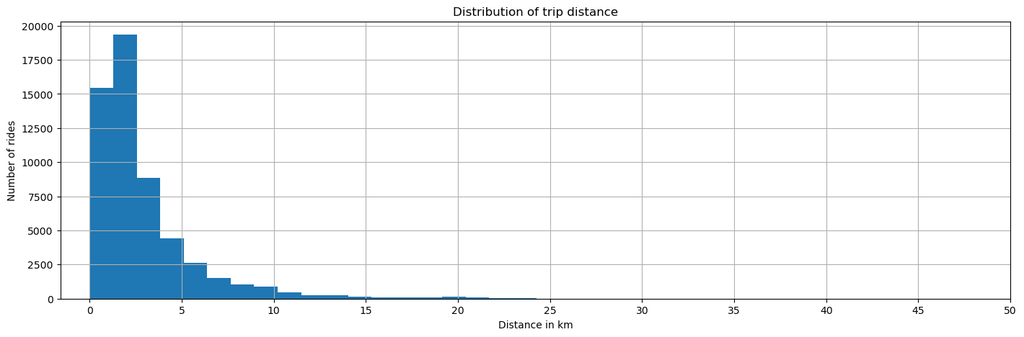

```python
plt.figure(figsize=(17,5))
df_cleaned[df_cleaned['distance'] < 50]['distance'].hist(bins = 25)

plt.title('Distribution of trip distance')
plt.xlabel('Distance in km')
plt.ylabel('Number of rides')
plt.xticks(np.arange(0,51,5))

plt.show();
```

## Handlimg date time issue

`pickup_datetime` and `dropoff_datetime` features have date and time combined what makes them hard to work with. So just to see if these features can be valuable for us we'll decompose them.

```python
# all features need to be extracted from orig. data if i want to use them in model
df_cleaned['pickup_hour'] = df_cleaned['pickup_datetime'].dt.hour
df_cleaned['pickup_day'] = df_cleaned['pickup_datetime'].dt.day
df_cleaned['pickup_month'] = df_cleaned['pickup_datetime'].dt.month
df_cleaned['pickup_weekday'] = df_cleaned['pickup_datetime'].dt.weekday

df_cleaned['dropoff_hour'] = df_cleaned['dropoff_datetime'].dt.hour
df_cleaned['dropoff_day'] = df_cleaned['dropoff_datetime'].dt.day
df_cleaned['dropoff_month'] = df_cleaned['dropoff_datetime'].dt.month
df_cleaned['dropoff_weekday'] = df_cleaned['dropoff_datetime'].dt.weekday
```

```python
# now drop redundant data cols
df_cleaned = df_cleaned.drop(['pickup_datetime', 'dropoff_datetime'], axis=1)
```

Now we have new features: pickup and dropoff hour, day, month and day of the week.

```python
df_cleaned.head()
```

|  | id | vendor_id | passenger_count | pickup_longitude | pickup_latitude | dropoff_longitude | dropoff_latitude | store_and_fwd_flag | trip_duration | st_flag | log_trip_duration | distance | pickup_hour | pickup_day | pickup_month | pickup_weekday | dropoff_hour | dropoff_day | dropoff_month | dropoff_weekday |
| --- | --- | --- | --- | --- | --- | --- | --- | --- | --- | --- | --- | --- | --- | --- | --- | --- | --- | --- | --- | --- |
| 0 | 2875421 | 2 | 1 | -73.982155 | 40.767937 | -73.964630 | 40.765602 | N | 455.0 | 0 | 6.120297 | 1.502172 | 17 | 14 | 3 | 0 | 17 | 14 | 3 | 0 |
| 1 | 2377394 | 1 | 1 | -73.980415 | 40.738564 | -73.999481 | 40.731152 | N | 663.0 | 0 | 6.496775 | 1.808660 | 0 | 12 | 6 | 6 | 0 | 12 | 6 | 6 |
| 3 | 3504673 | 2 | 1 | -74.010040 | 40.719971 | -74.012268 | 40.706718 | N | 429.0 | 0 | 6.061457 | 1.483632 | 19 | 6 | 4 | 2 | 19 | 6 | 4 | 2 |
| 4 | 2181028 | 2 | 1 | -73.973053 | 40.793209 | -73.972923 | 40.782520 | N | 435.0 | 0 | 6.075346 | 1.187038 | 13 | 26 | 3 | 5 | 13 | 26 | 3 | 5 |
| 5 | 0801584 | 2 | 6 | -73.982857 | 40.742195 | -73.992081 | 40.749184 | N | 443.0 | 0 | 6.093570 | 1.099625 | 22 | 30 | 1 | 5 | 22 | 30 | 1 | 5 |

### A small sidestep to see what this gave us

```python
# Group pickups by vendor and hour.

total_pickups_h = df_cleaned.groupby(['vendor_id'])['pickup_hour'].value_counts()
total_pickups_h = pd.DataFrame(total_pickups_h).reset_index()
```

We can see the distribution of total pickups by hour for each vendor. See if it helps

```python
# Table of pickups by hour for each vendor with differences in rides
wd_pivot = total_pickups_h.pivot(index='pickup_hour', columns='vendor_id', values='count')
wd_pivot['difference'] = wd_pivot[1] - wd_pivot[2]
```

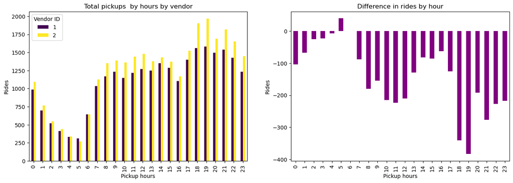

```python
fig, ax = plt.subplots(1,2, figsize=(16, 5))

wd_pivot[[1,2]].plot(kind='bar', stacked=False, colormap='viridis', ax=ax[0])
ax[0].set_title('Total pickups  by hours by vendor')
ax[0].set_xlabel('Pickup hours')
ax[0].set_ylabel('Rides')
ax[0].legend(title='Vendor ID');

wd_pivot['difference'].plot(kind='bar', color='purple', ax=ax[1])
ax[1].set_title('Difference in rides by hour')
ax[1].set_xlabel('Pickup hours')
ax[1].set_ylabel('Rides');
```

We can see that in the night/morning hours the number of rides is more or less equal, but the difference escalates closer to the rush morning (with lower magnitude) and evening (higher magnitude) hours.

These are the hours where Vendor 1 underperformes.

Same way we can analyze the difference by days and months and add more depth by considering the passengers groups. But thtaa's a major sidestep from the purpose towards EDA.

```python
# Group pickups by vendor and day.

total_pickups_d = df_cleaned.groupby(['vendor_id'])['pickup_day'].value_counts()
total_pickups_d = pd.DataFrame(total_pickups_d).reset_index()
```

```python
# Table of pickups by hour for each vendor with differences in rides
wd_pivot_d = total_pickups_d.pivot(index='pickup_day', columns='vendor_id', values='count')
wd_pivot_d['difference'] = wd_pivot_d[1] - wd_pivot_d[2]
```

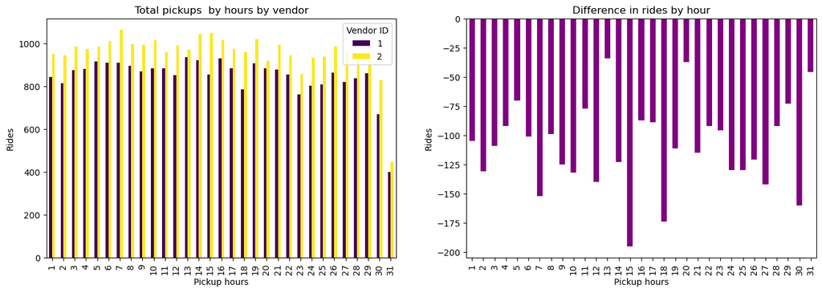

```python
fig, ax = plt.subplots(1,2, figsize=(16, 5))

wd_pivot_d[[1,2]].plot(kind='bar', stacked=False, colormap='viridis', ax=ax[0])
ax[0].set_title('Total pickups  by hours by vendor')
ax[0].set_xlabel('Pickup hours')
ax[0].set_ylabel('Rides')
ax[0].legend(title='Vendor ID');

wd_pivot_d['difference'].plot(kind='bar', color='purple', ax=ax[1])
ax[1].set_title('Difference in rides by hour')
ax[1].set_xlabel('Pickup hours')
ax[1].set_ylabel('Rides');
```

Vendor 1 performance is lower through every day.

```python
# Group pickups by vendor and day,
total_pvp = df_cleaned.groupby(['passenger_count', 'vendor_id'])['pickup_hour'].value_counts()
total_pvp = pd.DataFrame(total_pvp).reset_index()
```

```python
total_pvp
```

|  | passenger_count | vendor_id | pickup_hour | count |
| --- | --- | --- | --- | --- |
| 0 | 1 | 1 | 19 | 1273 |
| 1 | 1 | 1 | 18 | 1252 |
| 2 | 1 | 1 | 21 | 1189 |
| 3 | 1 | 1 | 20 | 1179 |
| 4 | 1 | 1 | 17 | 1138 |
| ... | ... | ... | ... | ... |
| 247 | 6 | 2 | 6 | 46 |
| 248 | 6 | 2 | 3 | 31 |
| 249 | 6 | 2 | 2 | 27 |
| 250 | 6 | 2 | 4 | 27 |
| 251 | 6 | 2 | 5 | 18 |

252 rows × 4 columns

```python
pvp = total_pvp.pivot(index='pickup_hour', columns=['vendor_id', 'passenger_count'], values='count')
pvp = pvp.fillna(0)
pvp.head()
```

| vendor_id passenger_count pickup_hour | 1 | 2 1 | 1 2 | 2 | 1 3 | 2 3 | 1 4 | 2 4 | 1 5 | 2 5 | 1 6 | 2 6 |
| --- | --- | --- | --- | --- | --- | --- | --- | --- | --- | --- | --- | --- |
| 0 | 763.0 | 649.0 | 171.0 | 179.0 | 37.0 | 60.0 | 16.0 | 32.0 | 0.0 | 124.0 | 0.0 | 47.0 |
| 1 | 537.0 | 471.0 | 129.0 | 112.0 | 21.0 | 34.0 | 12.0 | 13.0 | 0.0 | 79.0 | 0.0 | 57.0 |
| 2 | 406.0 | 332.0 | 83.0 | 82.0 | 18.0 | 27.0 | 15.0 | 15.0 | 0.0 | 64.0 | 0.0 | 27.0 |
| 3 | 320.0 | 255.0 | 66.0 | 63.0 | 18.0 | 33.0 | 9.0 | 7.0 | 1.0 | 48.0 | 0.0 | 31.0 |
| 4 | 267.0 | 205.0 | 43.0 | 48.0 | 16.0 | 15.0 | 4.0 | 9.0 | 0.0 | 33.0 | 0.0 | 27.0 |

```python
difference = pvp.xs(1, level='vendor_id', axis=1) - pvp.xs(2, level='vendor_id', axis=1)
difference.columns = [f'diff_passengers{col}' for col in difference.columns]
pvp.columns = [f'vendor_{col[0]}_passenger_{col[1]}' for col in pvp.columns]
result = pd.concat([pvp, difference], axis=1)
```

```python
result.head() # positive difference means advantage of vendor 1, negative -- advantage of vendor 2
```

| pickup_hour | vendor_1_passenger_1 | vendor_2_passenger_1 | vendor_1_passenger_2 | vendor_2_passenger_2 | vendor_1_passenger_3 | vendor_2_passenger_3 | vendor_1_passenger_4 | vendor_2_passenger_4 | vendor_1_passenger_5 | vendor_2_passenger_5 | vendor_1_passenger_6 | vendor_2_passenger_6 | diff_passengers1 | diff_passengers2 | diff_passengers3 | diff_passengers4 | diff_passengers5 | diff_passengers6 |
| --- | --- | --- | --- | --- | --- | --- | --- | --- | --- | --- | --- | --- | --- | --- | --- | --- | --- | --- |
| 0 | 763.0 | 649.0 | 171.0 | 179.0 | 37.0 | 60.0 | 16.0 | 32.0 | 0.0 | 124.0 | 0.0 | 47.0 | 114.0 | -8.0 | -23.0 | -16.0 | -124.0 | -47.0 |
| 1 | 537.0 | 471.0 | 129.0 | 112.0 | 21.0 | 34.0 | 12.0 | 13.0 | 0.0 | 79.0 | 0.0 | 57.0 | 66.0 | 17.0 | -13.0 | -1.0 | -79.0 | -57.0 |
| 2 | 406.0 | 332.0 | 83.0 | 82.0 | 18.0 | 27.0 | 15.0 | 15.0 | 0.0 | 64.0 | 0.0 | 27.0 | 74.0 | 1.0 | -9.0 | 0.0 | -64.0 | -27.0 |
| 3 | 320.0 | 255.0 | 66.0 | 63.0 | 18.0 | 33.0 | 9.0 | 7.0 | 1.0 | 48.0 | 0.0 | 31.0 | 65.0 | 3.0 | -15.0 | 2.0 | -47.0 | -31.0 |
| 4 | 267.0 | 205.0 | 43.0 | 48.0 | 16.0 | 15.0 | 4.0 | 9.0 | 0.0 | 33.0 | 0.0 | 27.0 | 62.0 | -5.0 | 1.0 | -5.0 | -33.0 | -27.0 |

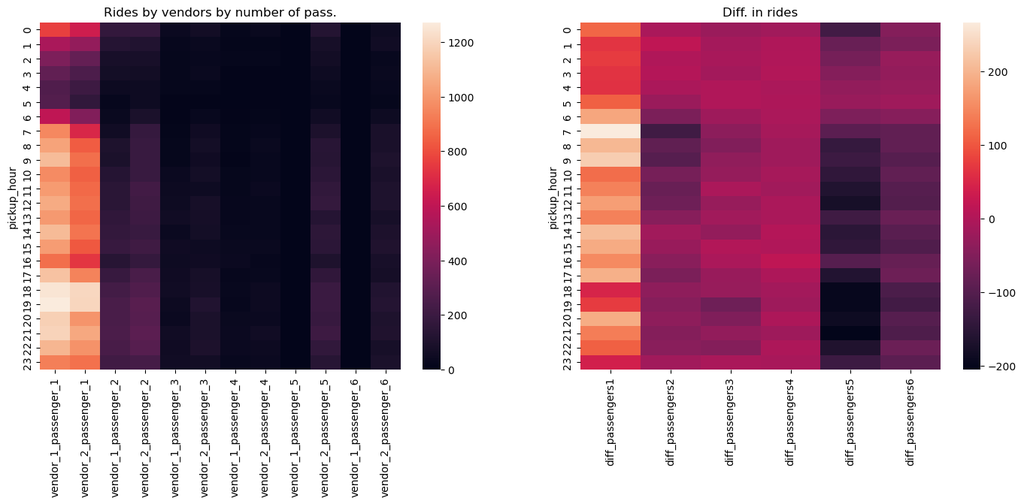

```python
fig, ax = plt.subplots(1,2, figsize=(17,6))

sns.heatmap(result.iloc[:, :12], ax=ax[0])
ax[0].set_title('Rides by vendors by number of pass.')

sns.heatmap(result.iloc[:, 12:], ax=ax[1])
ax[1].set_title('Diff. in rides');
```

The diff heatmap is more useful. Here the bright colors mean that Vendor 1 has advantage, dark cells show Vendor 2 has advantage.

Both vendors don't have lots of customers for 3 to 4 passengers rides.

## Check for correlation

```python
df_cleaned.info()
```

```
<class 'pandas.core.frame.DataFrame'>
Index: 55800 entries, 0 to 58757
Data columns (total 20 columns):
 #   Column              Non-Null Count  Dtype
---  ------              --------------  -----
 0   id                  55800 non-null  object
 1   vendor_id           55800 non-null  int8
 2   passenger_count     55800 non-null  int8
 3   pickup_longitude    55800 non-null  float32
 4   pickup_latitude     55800 non-null  float32
 5   dropoff_longitude   55800 non-null  float32
 6   dropoff_latitude    55800 non-null  float32
 7   store_and_fwd_flag  55800 non-null  object
 8   trip_duration       55800 non-null  float64
 9   st_flag             55800 non-null  int64
 10  log_trip_duration   55800 non-null  float64
 11  distance            55800 non-null  float64
 12  pickup_hour         55800 non-null  int32
 13  pickup_day          55800 non-null  int32
 14  pickup_month        55800 non-null  int32
 15  pickup_weekday      55800 non-null  int32
 16  dropoff_hour        55800 non-null  int32
 17  dropoff_day         55800 non-null  int32
 18  dropoff_month       55800 non-null  int32
 19  dropoff_weekday     55800 non-null  int32
dtypes: float32(4), float64(3), int32(8), int64(1), int8(2), object(2)
memory usage: 7.7+ MB
```

```python
df_cleaned.drop(columns='store_and_fwd_flag', inplace=True)
```

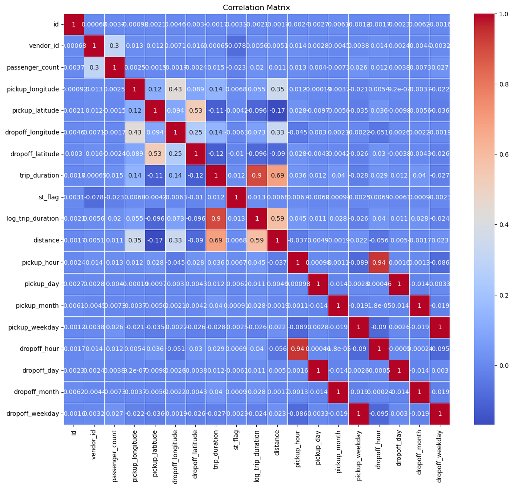

```python
df_matrix = df_cleaned.corr()

plt.figure(figsize=(14, 12))
sns.heatmap(df_matrix, annot=True, cmap='coolwarm', linewidths=0.5)
plt.title('Correlation Matrix')
plt.show();
```

We see strong positive correlation between the new-made feature `distance` and `trip_duration`. But not strong enough to cause multicollinearity.

The longitude vars have stronger positive correlation with distance than lat vars that have slightly negative correlation, like if people for longer trips go more north-south than east-west. That aligns with the shape of the area.

Since we removed the outliers we need no more the log-transformed var for trip duration, especially considering that its coeff. of correlation with the duration is weaker than the original's coefficient. So before modelling we can remove it.

Determine doubling features to be removed from dataset before modelling

```python
threshold = 0.8
highly_correlated = [(feature1, feature2) for feature1 in df_matrix.columns for feature2 in df_matrix.columns if feature1 != feature2 and abs(df_matrix.loc[feature1, feature2]) > threshold]
highly_correlated
```

```
[('trip_duration', 'log_trip_duration'),
 ('log_trip_duration', 'trip_duration'),
 ('pickup_hour', 'dropoff_hour'),
 ('pickup_day', 'dropoff_day'),
 ('pickup_month', 'dropoff_month'),
 ('pickup_weekday', 'dropoff_weekday'),
 ('dropoff_hour', 'pickup_hour'),
 ('dropoff_day', 'pickup_day'),
 ('dropoff_month', 'pickup_month'),
 ('dropoff_weekday', 'pickup_weekday')]
```

```python
df_cleaned.head()
```

|  | id | vendor_id | passenger_count | pickup_longitude | pickup_latitude | dropoff_longitude | dropoff_latitude | trip_duration | st_flag | log_trip_duration | distance | pickup_hour | pickup_day | pickup_month | pickup_weekday | dropoff_hour | dropoff_day | dropoff_month | dropoff_weekday |
| --- | --- | --- | --- | --- | --- | --- | --- | --- | --- | --- | --- | --- | --- | --- | --- | --- | --- | --- | --- |
| 0 | 2875421 | 2 | 1 | -73.982155 | 40.767937 | -73.964630 | 40.765602 | 455.0 | 0 | 6.120297 | 1.502172 | 17 | 14 | 3 | 0 | 17 | 14 | 3 | 0 |
| 1 | 2377394 | 1 | 1 | -73.980415 | 40.738564 | -73.999481 | 40.731152 | 663.0 | 0 | 6.496775 | 1.808660 | 0 | 12 | 6 | 6 | 0 | 12 | 6 | 6 |
| 3 | 3504673 | 2 | 1 | -74.010040 | 40.719971 | -74.012268 | 40.706718 | 429.0 | 0 | 6.061457 | 1.483632 | 19 | 6 | 4 | 2 | 19 | 6 | 4 | 2 |
| 4 | 2181028 | 2 | 1 | -73.973053 | 40.793209 | -73.972923 | 40.782520 | 435.0 | 0 | 6.075346 | 1.187038 | 13 | 26 | 3 | 5 | 13 | 26 | 3 | 5 |
| 5 | 0801584 | 2 | 6 | -73.982857 | 40.742195 | -73.992081 | 40.749184 | 443.0 | 0 | 6.093570 | 1.099625 | 22 | 30 | 1 | 5 | 22 | 30 | 1 | 5 |

# Modelling

```python
def get_mae(model):

    y_train_pred = model.predict(X_train)
    y_test_pred = model.predict(X_test)

    # Eval on training set
    train_mse = mean_squared_error(y_train, y_train_pred)
    train_r2 = r2_score(y_train, y_train_pred)

    # Eval on test set
    test_mse = mean_squared_error(y_test, y_test_pred)
    test_r2 = r2_score(y_test, y_test_pred)

    print('Train evaluation:')
    print(f'MSE: {train_mse:.4f}')
    print(f'RMSE: {(train_mse)**0.5:.4f}')
    print(f'R^2: {train_r2:.4f}')

    print('\nTest evaluation:')
    print(f'MSE: {test_mse:.4f}')
    print(f'RMSE: {(test_mse)**0.5:.4f}')
    print(f'R^2: {test_r2:.4f}')
```

## Splitting dataset

```python
df_cleaned.columns
```

```
Index(['id', 'vendor_id', 'passenger_count', 'pickup_longitude',
       'pickup_latitude', 'dropoff_longitude', 'dropoff_latitude',
       'trip_duration', 'st_flag', 'log_trip_duration', 'distance',
       'pickup_hour', 'pickup_day', 'pickup_month', 'pickup_weekday',
       'dropoff_hour', 'dropoff_day', 'dropoff_month', 'dropoff_weekday'],
      dtype='object')
```

```python
dfc = df_cleaned.drop(columns=['pickup_hour', 'pickup_day', 'pickup_month', 'pickup_weekday']) # so that we gould easily go back
```

```python
X = dfc.drop(['trip_duration', 'log_trip_duration'], axis=1)
y = dfc['trip_duration']
```

```python
X.head(1)
```

|  | id | vendor_id | passenger_count | pickup_longitude | pickup_latitude | dropoff_longitude | dropoff_latitude | st_flag | distance | dropoff_hour | dropoff_day | dropoff_month | dropoff_weekday |
| --- | --- | --- | --- | --- | --- | --- | --- | --- | --- | --- | --- | --- | --- |
| 0 | 2875421 | 2 | 1 | -73.982155 | 40.767937 | -73.96463 | 40.765602 | 0 | 1.502172 | 17 | 14 | 3 | 0 |

```python
X_train, X_test, y_train, y_test = train_test_split(X, y, test_size=0.2, random_state=888)
```

## Scale

```python
scaler = StandardScaler()

X_train = scaler.fit_transform(X_train)
X_test = scaler.transform(X_test)
```

## Build model

### Linear regression

```python
linreg = LinearRegression()
linreg.fit(X_train, y_train)
```

```
LinearRegression()
```

```python
get_mae(linreg)
```

[output not shown]

```python
intercept = round(linreg.intercept_, 3)
slope = round(linreg.coef_[0], 3)
print(f'Intercept: {intercept}, \nSlope: {slope}')
```

```
Intercept: 731.634,
Slope: -1.604
```

```python
linreg.coef_
```

```
array([ -1.60361442,  -1.34967736,   3.11118082, -47.12308066,
        25.38608307, -20.87818429, -28.27877326,   2.16834686,
       335.69092303,  29.10406809,   3.53897679,  19.70575437,
       -16.81689829])
```

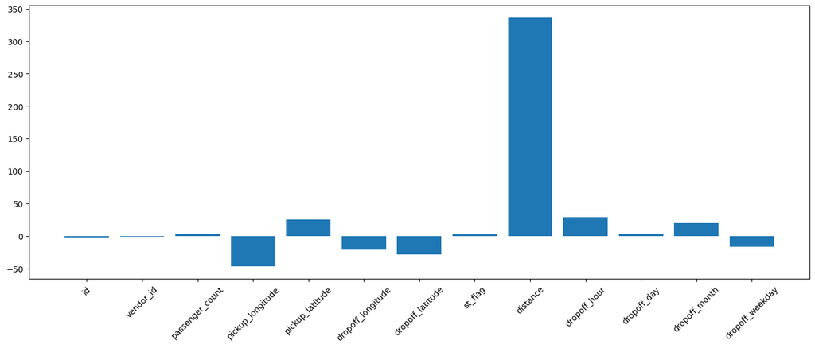

```python
plt.figure(figsize=(17,6))
plt.xticks(rotation=45)
plt.bar(X.columns, linreg.coef_);
```

### Random Forest

```python
from sklearn.ensemble import RandomForestRegressor
```

```python
rfr = RandomForestRegressor(n_estimators=200).fit(X_train, y_train)
```

```python
get_mae(rfr)
```

[output not shown]

```python
importances = rfr.feature_importances_
```

```python
feature_importances = pd.DataFrame({
    'Feature': X.columns,
    'Importance': importances
})
feature_importances = feature_importances.sort_values(by='Importance')
```

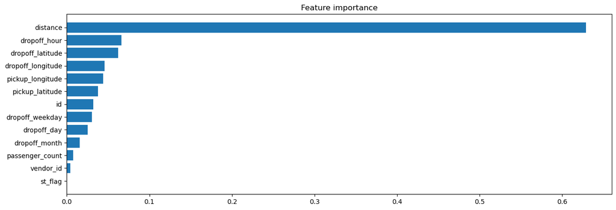

```python
plt.figure(figsize=(15,5))
plt.barh(feature_importances['Feature'], feature_importances['Importance'])

plt.title("Feature importance");
```

R^2 is much better than with the baseline model.

This is a very small dataset, with only about 60,000 data points and a small number of variables. Within this dataset, it is unlikely to achieve a better R^2 score — these predictors are insufficient for building a better model. It would be possible to use external datasets, such as more precise geodata or data on trip costs.